# Effects of Promotions on the Sale of GM Cereals

Glen Lewis

# 1 Hypothesizes and Assessment Criteria

H1<sub>0</sub> = Promotions did not impact sales of GM cereal products  
H1<sub>A</sub> = Promotions did impact the sales of GM cereal products

*H1 assess how effective GM promotions are at increasing sales.*

The impact of a type I error would be to create a perceived business environment where decision makers believe their promotion efforts have an influence on increasing sales when they are not. This environment may lead to decision-making that continues following a strategy that is unknowingly ineffective, leading to flat if not declining sales.

The impact of a type II error is interesting in that it would great a perceived business environment where decision makers believe their promotion efforts are ineffective at influencing sales when they are. This environment may lead to the unnecessary adoption of a new strategy or the wasteful allocates of resources to produce an effect that is already occurring. Those decisions: however, could also expand/grow the positive effects their current promotion strategies are having.

A type I error could lead to flat sales - a significant opportunity cost – that grows which each passing day. A type II error may or may not have a negative impact on future sales depending; thus, we consider a type I error as the bigger risk. Therefore, the study will set alpha to .05 minimizing the potential for a type I error when answering H1.

H2<sub>0</sub> = GM promotion techniques were not more effective than other Brands’ promotion techniques  
H2<sub>A</sub> = GM promotion techniques were more effective than other Brands’ promotion techniques.

*H2 assess how effective GM sale promotions are in raising sales vis-a-vis it’s competitors’ promotions’ efforts.*

The impact of a type I error would create a perceived business environment where decision makers believe their promotion techniques are more effect than the competitions. This environment may lead to decision-making to continue following a strategy that is ineffective and unknowingly opening market expansion opportunities to competitors.

The impact of a type II error is like a type II error for H1. While it could lead to the unnecessary allocation of resources, that reallocation could augment the competitive advantage its current efforts are unknowing creating.

A type I error could lead to a loss of market share, something GM could not easily regain without significant effort and cost. A type II error may or may not have a negative impact on future sales depending; thus, we consider a type I error as the bigger risk. Therefore, the study will set alpha to .05 minimizing the potential for a type I error when answering H2.

# 2 Libraries

```r
library(tidyverse) # For cleaning data.
library(lubridate) # For date conversions.
library(vtable) # To conduct descriptive EDA.
library(janitor) # For multi-variable cross table builds.
library(jtools) # For reviewing and plotting lm relationships.
library(car) # For hypothesis testing.
library(scales) # To get convert axis scales and labels.
library(ggannotate) # For annotations.
library(patchwork) # Use to put graphs together (faceting) in the same frame.
library(colorspace)
library(knitr) # Enable kableExtra integration.
library(kableExtra) # For formatting tables.
library(here) # For saving plots to specific folders.
```

# 3 Load and Transforming Data

```r
# Following loads the data csv's into the environment via a base_product_data and base_sales_data objects.

base_product_data <- read_csv('mtp_product_data.csv')
base_sales_data <- read_csv('mtp_sales_data.csv')

# head(base_product_data, 10)
# NOTE: For small data sets with few variables head easier than vtable.

# FOR ACTION: (1) Standardize UPCs in both data sets to act as a key for a join. (2) Join the to data sets into a single base set. (3) Convert the promo and add variables to factors. (4) Convert week numbers variables into dates: 'week_of' variable

wip_product_data <- base_product_data %>%
  mutate(UPC = str_remove(UPC, '^00-')) %>%
  # removes the 00- characters from the UPC
  mutate(UPC = str_replace_all(UPC, '-', '\\.')) %>%
  # replaces the - in the UPC with a '.'.  This is need to setup a key for the join.
  mutate(brand = str_replace(brand, '^GENERAL MILLS', 'GENERAL_MILLS')) %>%
  # replaces the " " with '_' enabling easy separation and manipulation of variables.
  mutate(brand = str_replace(brand, ' ', '\\\\')) %>%
  # replaces the first ' ' with a '\' so the col can be easily separated into maker and brand.
  separate(brand, c('maker', 'brand'), sep = '\\\\') %>%
  mutate(brand = str_replace_all(brand, ' ', '_'))
  # replaces the " " with '_' enabling easy separation and manipulation of variables.

# Joins the 2 tables into a single complete dataframe using UPC as the key.
wip_cereal_data <- wip_product_data %>%
  left_join(base_sales_data, 'UPC')

# The following converts variables from class char/numeric to factor as required.
# Uses lubridate to convert week numbers into actual dates.  No year for the data was given so assumed 2019.
# Base precedes a data sets that are considered the base from which additional cleaning, tidying, EAD will be conducted from.
base_cereal_data <- wip_cereal_data %>%
  mutate(across(c(maker, brand, package, promo, ad), as.factor)) %>%
  mutate(week_of = ymd('2019/01/01') + weeks(week - 1))

vtable(base_cereal_data)
```

base_cereal_data

| Name | Class | Values |
| --- | --- | --- |
| UPC | character |  |
| maker | factor | ‘GENERAL_MILLS’ ‘KELLOGGS’ ‘POST’ |
| brand | factor | ‘CHEERIOS’ ‘CINNAMON_TST_CR’ ‘COCOA_KRISPIES’ ‘COCOA_PUFFS’ ‘FROOT_LOOPS’ and more |
| flavor | character |  |
| volume | numeric | Num: 0.04 to 4 |
| package | factor | ‘BOX’ ‘CUP’ |
| iri_key | numeric | Num: 200171 to 8057418 |
| week | numeric | Num: 1 to 52 |
| units | numeric | Num: 1 to 28 |
| price | numeric | Num: 0.25 to 9.99 |
| promo | factor | ‘0’ ‘1’ |
| ad | factor | ‘A’ ‘B’ ‘NONE’ |
| week_of | Date | Time: 2019-01-01 to 2019-12-24 |

```r
write_csv(base_cereal_data, 'base_cereal_data.csv')
```

# 4 Base EDA Step 1: Uni-variate non-graphical EDA

```r
# The following reviews the individuals variables.  Focuses on classes of variables.
vtable(base_cereal_data, lush = TRUE)
```

base_cereal_data

| Name | Class | Values | Missing | Summary |
| --- | --- | --- | --- | --- |
| UPC | character | ‘01.16000.11653’ ‘01.16000.11945’ ‘01.16000.14154’ ‘01.16000.14156’ ‘01.16000.14159’ and more | 0 | nuniq: 114 |
| maker | factor | ‘GENERAL_MILLS’ ‘KELLOGGS’ ‘POST’ | 0 | nuniq: 3 |
| brand | factor | ‘CHEERIOS’ ‘CINNAMON_TST_CR’ ‘COCOA_KRISPIES’ ‘COCOA_PUFFS’ ‘FROOT_LOOPS’ and more | 0 | nuniq: 15 |
| flavor | character | ‘CINNAMON TOAST’ ‘COCOA’ ‘FRUIT’ ‘REGULAR’ ‘TOASTED’ | 0 | nuniq: 5 |
| volume | numeric | Num: 0.04 to 4 | 0 | mean: 1.016, sd: 0.37, nuniq: 51 |
| package | factor | ‘BOX’ ‘CUP’ | 0 | nuniq: 2 |
| iri_key | numeric | Num: 200171 to 8057418 | 0 | mean: 454405.458, sd: 550431.063, nuniq: 1420 |
| week | numeric | Num: 1 to 52 | 0 | mean: 26.618, sd: 14.895, nuniq: 52 |
| units | numeric | Num: 1 to 28 | 0 | mean: 8.579, sd: 6.702, nuniq: 28 |
| price | numeric | Num: 0.25 to 9.99 | 0 | mean: 3.763, sd: 0.997, nuniq: 485 |
| promo | factor | ‘0’ ‘1’ | 0 | nuniq: 2 |
| ad | factor | ‘A’ ‘B’ ‘NONE’ | 0 | nuniq: 3 |
| week_of | Date | Time: 2019-01-01 to 2019-12-24 | 0 | mean: 18076.3252631579, sd: 104.262, nuniq: 52 |

```r
# The following is used to get a better understand on central tendencies and skew.
summary(base_cereal_data)
```

```
##      UPC                      maker                       brand
##  Length:21850       GENERAL_MILLS: 7189   FROSTED_FLAKES     : 2295
##  Class :character   KELLOGGS     :12183   FROOT_LOOPS        : 2192
##  Mode  :character   POST         : 2478   CINNAMON_TST_CR    : 1834
##                                           LUCKY_CHARMS       : 1681
##                                           FROSTED_MINI_WHEATS: 1574
##                                           CHEERIOS           : 1458
##                                           (Other)            :10816
##     flavor              volume      package        iri_key
##  Length:21850       Min.   :0.040   BOX:21306   Min.   : 200171
##  Class :character   1st Qu.:0.750   CUP:  544   1st Qu.: 241553
##  Mode  :character   Median :1.060               Median : 273720
##                     Mean   :1.016               Mean   : 454405
##                     3rd Qu.:1.120               3rd Qu.: 648547
##                     Max.   :4.000               Max.   :8057418
##
##       week           units            price       promo        ad
##  Min.   : 1.00   Min.   : 1.000   Min.   :0.250   0:17305   A   : 1456
##  1st Qu.:14.00   1st Qu.: 3.000   1st Qu.:3.190   1: 4545   B   : 1061
##  Median :27.00   Median : 7.000   Median :3.790             NONE:19333
##  Mean   :26.62   Mean   : 8.579   Mean   :3.763
##  3rd Qu.:40.00   3rd Qu.:12.000   3rd Qu.:4.390
##  Max.   :52.00   Max.   :28.000   Max.   :9.990
##
##     week_of
##  Min.   :2019-01-01
##  1st Qu.:2019-04-02
##  Median :2019-07-02
##  Mean   :2019-06-29
##  3rd Qu.:2019-10-01
##  Max.   :2019-12-24
##
```

```r
# The data appears tidy, each variable to a column. The are several variables that could be viewed as a factor - such as UPC - but will convert as required in functions.
```

## 4.2 Questions:

1. Examine the impact for promo and ad on units sold, especially since they are so few.
2. What was the ad and promo duration - because they were long events the reason for so few across the year?

# 5 Base EDA Step 2: Uni-variate graphical EDA

```r
# The following will begin to look at trends in Kelloggs cereals as part of answering H2.
# Builds a kKlloggs base data set.
base_kelloggs_data <- base_cereal_data %>%
  filter(maker == 'KELLOGGS')

# Tallies the units sold by brands.
base_kelloggs_data %>%
  group_by (brand) %>%
  tally()
```

```
## # A tibble: 8 x 2
##   brand                   n
##   <fct>               <int>
## 1 COCOA_KRISPIES        881
## 2 FROOT_LOOPS          2192
## 3 FROSTED_FLAKES       2295
## 4 FROSTED_MINI_WHEATS  1574
## 5 RAISIN_BRAN          1266
## 6 RICE_KRISPIES        1450
## 7 SMART_START          1134
## 8 SPECIAL_K            1391
```

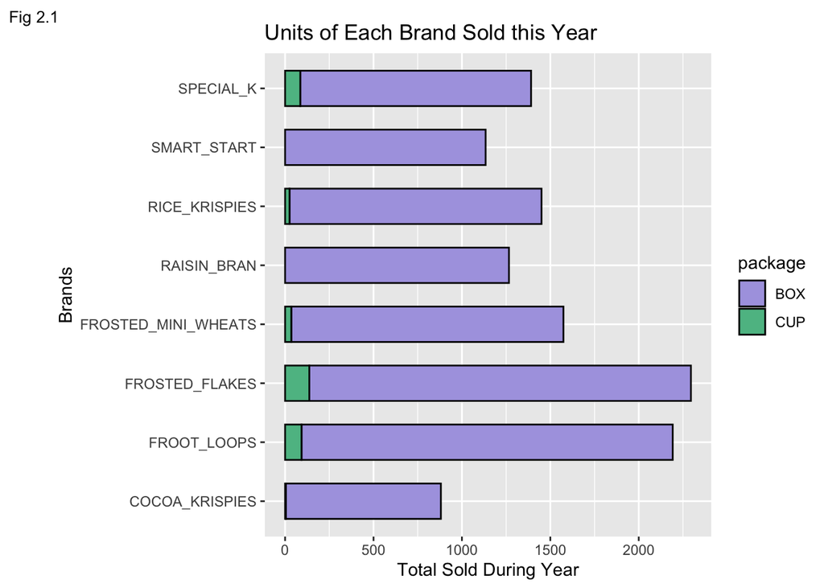

```r
# The following examines the Kellogg's brand variable.  The plot shows total brand sales for the year broken into cup and box sales.
kellogg_brand_summary_plot <- base_kelloggs_data %>% ggplot() +
  geom_bar(aes(x = brand, fill = package), color = 'black', width = .6) +
  # Uses fill to build a stacked bar to highlight cup and box sales. Width set a little bit smaller to ease reading. Added a black outline to help distiguish cup and box totals.
  coord_flip() +
  # Flips axis for ease of reading
  labs(title = "Units of Each Brand Sold this Year",
       x = 'Brands',
       y = 'Total Sold During Year',
       tag = 'Fig 2.1') +
  theme(plot.tag = element_text(size = 10)) +
  scale_fill_discrete_qualitative(palette = 'Cold')
  # Changes color tom something other than default.

kellogg_brand_summary_plot
```

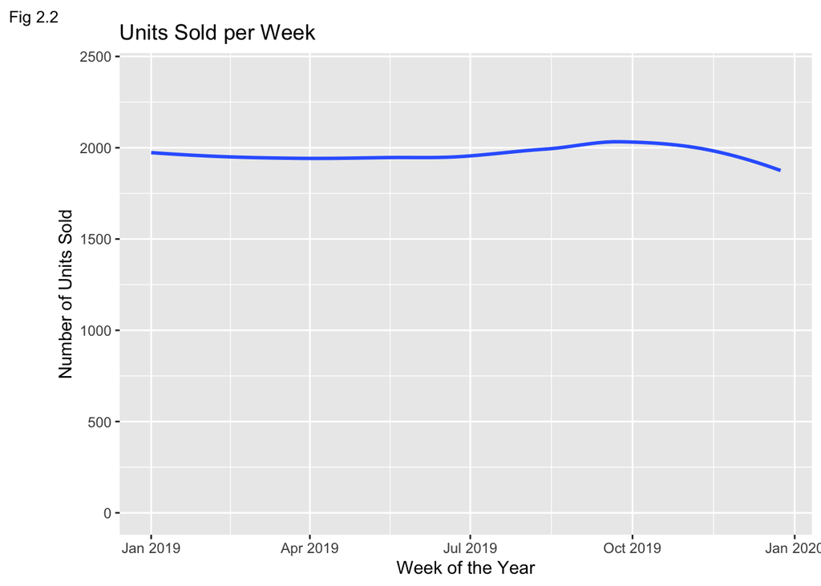

```r
# The following begins a review of units sold across the year.
kellogg_unit_sold_summary <-  base_kelloggs_data %>%
  group_by(week_of) %>%
  summarise(units_sold = sum(units)) %>%
  # Creates a variable summing up the units sold (regardless of brand) per week.
  ggplot() +
  geom_smooth(aes(x = week_of, y = units_sold), se = FALSE) +
  labs(title = "Units Sold per Week",
       x = 'Week of the Year',
       y = 'Number of Units Sold',
       tag = 'Fig 2.2') +
  theme(plot.tag = element_text(size = 10)) +
  ylim(0, 2400)
  # Changed the y limits.  The default ggplot y limits displayed a deceivingly steep drop off in units sold during 4th QTR CY.

kellogg_unit_sold_summary
```

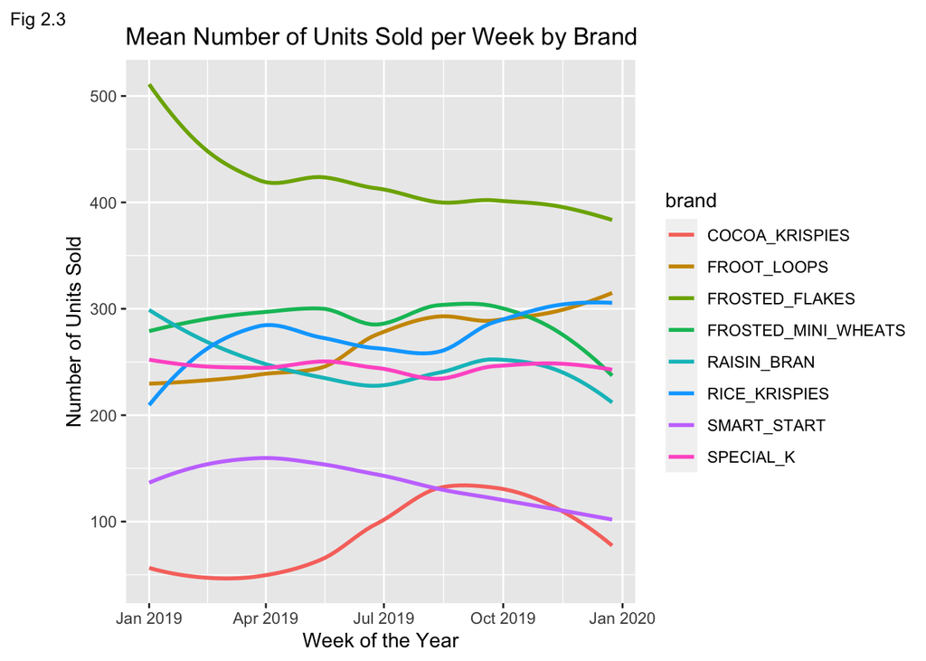

```r
# The following look at the number of units sold by brand. (Multi-Variate?)
kellogg_unit_sold_by_brand <-  base_kelloggs_data %>%
  group_by(brand, week_of) %>%
  summarise(units_sold = sum(units)) %>%
  ggplot() +
  geom_smooth(aes(x = week_of, y = units_sold, color = brand), se = FALSE) +
  labs(title = 'Mean Number of Units Sold per Week by Brand',
       x = 'Week of the Year',
       y = 'Number of Units Sold',
       tag = 'Fig 2.3') +
  theme(plot.tag = element_text(size = 10))

kellogg_unit_sold_by_brand
```

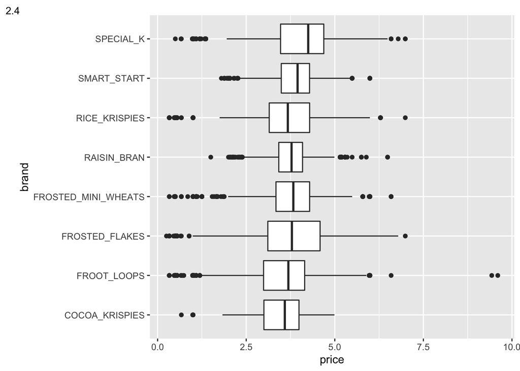

```r
# Following looks at the price variable.

# The following builds a boxplot showing the price ranges by brand.
base_kelloggs_data %>%
  ggplot() +
  geom_boxplot(aes(x = price, y = brand)) +
  labs(tag = '2.4') +
  theme(plot.tag = element_text(size = 10))
```

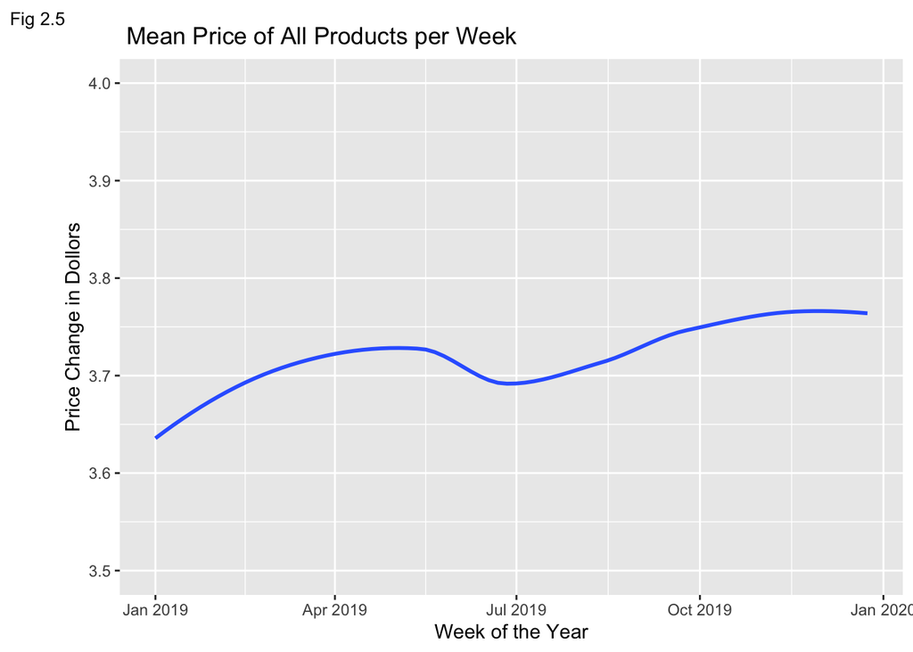

```r
# The following review the price variable by plotting median price (of all products) across the year.
kellogg_price_summary_plot <- base_kelloggs_data %>%
  group_by(week_of) %>%
  summarise(mean_weekly_price = mean(price)) %>%
  # Creates a weekly mean price of all products
  ggplot() +
  geom_smooth(aes(x = week_of, y = mean_weekly_price), se = FALSE) +
  scale_y_continuous(labels = dollar) +
  ylim(3.50, 4.00) +
  # Adjusted the y limits again.  The default ggplot y limits made the price swing look more dramatic than it really is.
  labs(title = ' Mean Price of All Products per Week',
       x = 'Week of the Year',
       y = 'Price Change in Dollors',
       tag = 'Fig 2.5') +
   theme(plot.tag = element_text(size = 10))

kellogg_price_summary_plot
```

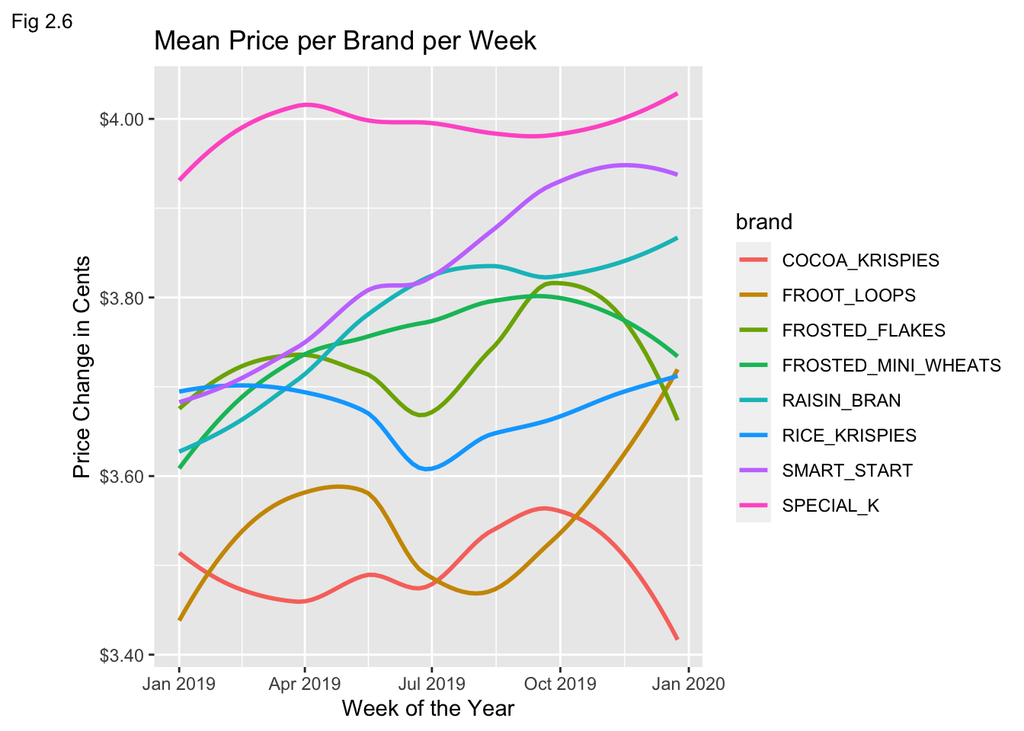

```r
# The following continues to look at the price variable by drilling down to see price by brand across the year.
kellogg_price_per_brand_plot <- base_kelloggs_data %>%
  group_by(brand, week_of) %>%
  summarise(mean_weekly_price_per_brand = mean(price)) %>%
  ggplot() +
  geom_smooth(aes(x = week_of, y = mean_weekly_price_per_brand, color = brand), se = FALSE) +
  scale_y_continuous(labels = dollar) +
  labs(title = 'Mean Price per Brand per Week',
       x = 'Week of the Year',
       y = 'Price Change in Cents',
       tag = 'Fig 2.6') +
  theme(plot.tag = element_text(size = 10))

kellogg_price_per_brand_plot
```

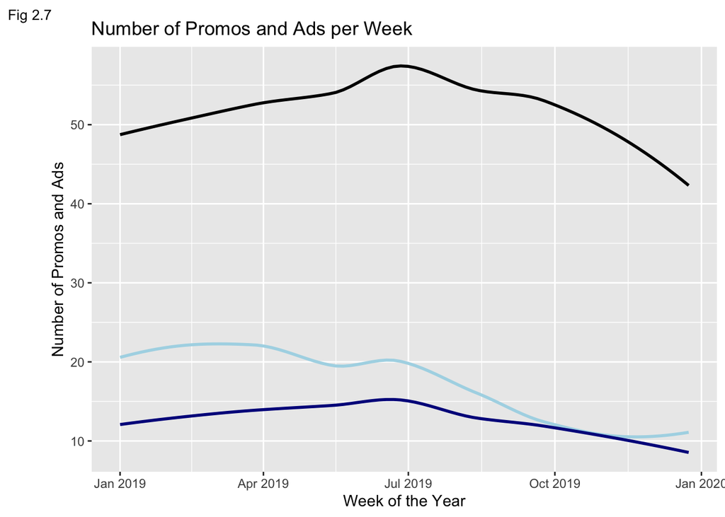

```r
# Following looks at promo and ad variable
kellogg_promo_ad_summary <- base_kelloggs_data %>%
  group_by(week_of) %>%
  summarise(total_promos = sum(promo == '1'),
            # Counts up the total number of promos per week.
            total_med_ad = sum(ad == "A"),
            # Counts up the total number of medium adds per week.
            total_small_ad = sum(ad == "B")) %>%
            # Counts up the total number of small ads per week.
  ggplot(aes(x = week_of)) +
  geom_smooth(aes(y = total_promos), color = 'black', se = FALSE) +
  geom_smooth(aes(y = total_med_ad), color = 'lightblue', se = FALSE) +
  geom_smooth(aes(y = total_small_ad), color = 'darkblue', se =FALSE) +
  labs(title = 'Number of Promos and Ads per Week',
       x = 'Week of the Year',
       y = 'Number of Promos and Ads',
       tag = 'Fig 2.7') +
  theme(plot.tag = element_text(size = 10))

kellogg_promo_ad_summary
```

## 5.2 Questions:

1. Is the increase in fourth quarter price an attempt to meet earning expectation?
2. What is Kellogg’s fiscal year? **Fiscal year is a 01/01 to 12/31 cycle.**
3. How does promo, ad, and total sale and/or individual product sales stack up?
4. What drove the bump in Special K sales?

# 6 Based EDA Step 3: Multi-variate non-grapgical EDA

```r
# The following looks at correlation between, price, vol.
cor_df <- base_kelloggs_data %>%
  select('price', 'volume')

round(cor(cor_df), 2) %>%
  kable()
```

|  | price | volume |
| --- | --- | --- |
| price | 1.00 | 0.53 |
| volume | 0.53 | 1.00 |

```r
#The following builds a table showing the total number of promos from across the year per brand broken down by ad.
base_kelloggs_data %>%
  tabyl(brand, promo, ad) %>%
  # The addition of ad creates an individual table for medium and small ads
  adorn_totals(where = c('row', 'col'))
```

```
## $A
##                brand   0   1 Total
##             CHEERIOS   0   0     0
##      CINNAMON_TST_CR   0   0     0
##       COCOA_KRISPIES  16  36    52
##          COCOA_PUFFS   0   0     0
##          FROOT_LOOPS  59  94   153
##       FROSTED_FLAKES  75  66   141
##  FROSTED_MINI_WHEATS  69  58   127
##           GRAPE_NUTS   0   0     0
##                  KIX   0   0     0
##         LUCKY_CHARMS   0   0     0
##          RAISIN_BRAN  37  30    67
##        RICE_KRISPIES  66  48   114
##       SHREDDED_WHEAT   0   0     0
##          SMART_START  56  68   124
##            SPECIAL_K  67  58   125
##                Total 445 458   903
##
## $B
##                brand   0   1 Total
##             CHEERIOS   0   0     0
##      CINNAMON_TST_CR   0   0     0
##       COCOA_KRISPIES   8  29    37
##          COCOA_PUFFS   0   0     0
##          FROOT_LOOPS  44  64   108
##       FROSTED_FLAKES  57  67   124
##  FROSTED_MINI_WHEATS  40  48    88
##           GRAPE_NUTS   0   0     0
##                  KIX   0   0     0
##         LUCKY_CHARMS   0   0     0
##          RAISIN_BRAN  16  31    47
##        RICE_KRISPIES  40  48    88
##       SHREDDED_WHEAT   0   0     0
##          SMART_START  25  65    90
##            SPECIAL_K  39  43    82
##                Total 269 395   664
##
## $NONE
##                brand    0    1 Total
##             CHEERIOS    0    0     0
##      CINNAMON_TST_CR    0    0     0
##       COCOA_KRISPIES  623  169   792
##          COCOA_PUFFS    0    0     0
##          FROOT_LOOPS 1570  361  1931
##       FROSTED_FLAKES 1687  343  2030
##  FROSTED_MINI_WHEATS 1139  220  1359
##           GRAPE_NUTS    0    0     0
##                  KIX    0    0     0
##         LUCKY_CHARMS    0    0     0
##          RAISIN_BRAN 1007  145  1152
##        RICE_KRISPIES 1056  192  1248
##       SHREDDED_WHEAT    0    0     0
##          SMART_START  731  189   920
##            SPECIAL_K  943  241  1184
##                Total 8756 1860 10616
```

## 6.2 Questions:

1. Is Smart Start targeted at a specific demographic?

# 7 Base EDA Step 4: Multi-variate graphical EDA

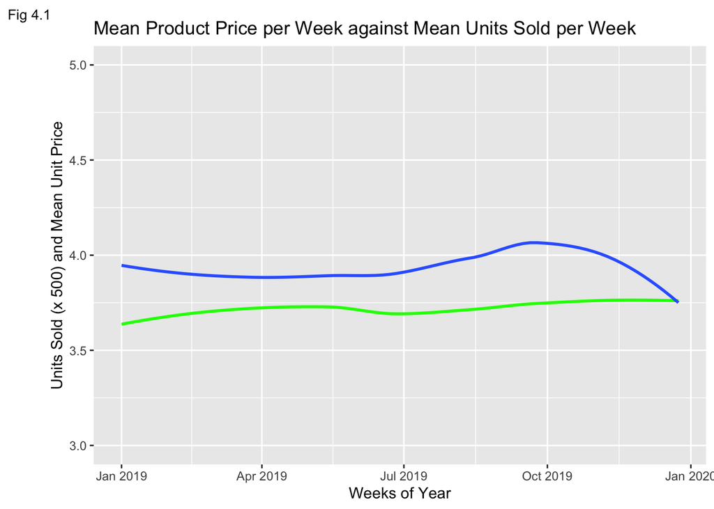

```r
# Following analysis will examine the units sold variable against several other variables.

# The first will examine total units sold over the year against ad, promos and price from across the year. This is a high level glance.
price_v_sold_summary <- base_kelloggs_data %>%
  group_by(week_of) %>%
  summarise(mean_price = round(mean(price), 2),
            units_sold = round(sum(units),0)) %>%
  ggplot(aes(x = week_of)) +
  geom_smooth(aes(y = mean_price), color = 'green', se = FALSE) +
  geom_smooth(aes(y = units_sold/500), se = FALSE) +
  # Scaled units sold to fit on y axis.
  labs(title = "Mean Product Price per Week against Mean Units Sold per Week",
       x = 'Weeks of Year',
       y = 'Units Sold (x 500) and Mean Unit Price',
       tag = 'Fig 4.1') +
  ylim(3.0, 5.0) +
  # Adjusted y limits again because the ggplot default the decline in units sold overly drastic.
  theme(plot.tag = element_text(size = 10))

price_v_sold_summary
```

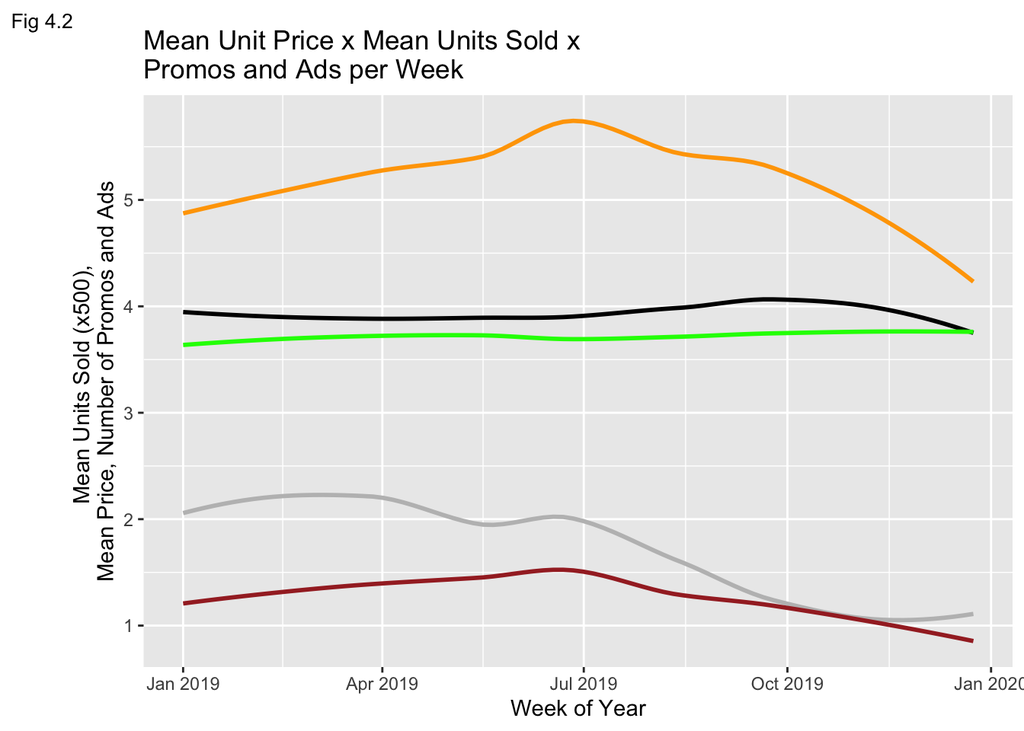

```r
# Following will continue the by adding promos and ads per week to the plot trying to tease out any relationship between them.
price_v_sold_promo_ad_summary <- base_kelloggs_data %>%
  group_by(week_of) %>%
  summarise(mean_price = round(mean(price), 2),
            units_sold = round(sum(units),0),
            total_promos = sum(promo == '1'),
            # Counts up the total number of promos per week.
            total_med_ad = sum(ad == "A"),
            # Counts up the total number of medium adds per week.
            total_small_ad = sum(ad == "B")) %>%
  ggplot(aes(x = week_of)) +
  geom_smooth(aes(y = (units_sold/500)), color = 'black', se = FALSE) +
  # Scaled down so information can be displayed on same y axis.
  geom_smooth(aes(y = mean_price),color = 'green', se = FALSE) +
  geom_smooth(aes(y = (total_promos/10)), color = 'orange', se = FALSE) +
  # Scaled down so information can be displayed on same y axis.
  geom_smooth(aes(y = total_med_ad/10), color = 'gray', se = FALSE) +
  # Scaled down so information can be displayed on same y axis.
  geom_smooth(aes(y = total_small_ad/10), color = 'brown', se = FALSE) +
  # Scaled down so information can be displayed on same y axis.
  labs(title = 'Mean Unit Price x Mean Units Sold x \nPromos and Ads per Week',
       x = 'Week of Year',
       y = 'Mean Units Sold (x500), \nMean Price, Number of Promos and Ads',
       tag = 'Fig 4.2') +
  theme(plot.tag = element_text(size = 10))

price_v_sold_promo_ad_summary
```

```r
# The next lines of code builds combo plots that looks at 6 brands mapping units sold, price, promo, ad across the year. The last chunk patches then all together.
smart_start_plot <- base_kelloggs_data %>%
  select('brand', 'week_of', 'units', 'price', 'promo', 'ad') %>%
  filter(brand == "SMART_START") %>%
  group_by(week_of) %>%
  summarise(mean_product_price = round(mean(price), 2),
            units_sold = round(sum(units),0),
            total_promos = sum(promo == '1'),
            # Counts up the total number of promos per week.
            total_med_ad = sum(ad == "A"),
            # Counts up the total number of medium adds per week.
            total_small_ad = sum(ad == "B")) %>%
  ggplot(aes(x = week_of)) +
  geom_smooth(aes(y = mean_product_price), se = FALSE) +
  geom_smooth(aes(y = (total_promos/2)), color = 'orange', se = FALSE) +
  # Scaled down so information can be displayed on same y axis.
  geom_smooth(aes(y = total_med_ad/2), color = 'gray', se = FALSE) +
  # Scaled down so information can be displayed on same y axis.
  geom_smooth(aes(y = total_small_ad/2), color = 'brown', se = FALSE) + geom_smooth(aes(y = units_sold/100), color = 'purple', se = FALSE) +
  # Scaled down so information can be displayed on same y axis.
  labs(title = 'Smart Start Combo',
       x = "Weeks of the Year")

frosted_flakes_plot <- base_kelloggs_data %>%
  select('brand', 'week_of', 'units', 'price', 'promo', 'ad') %>%
  filter(brand == "FROSTED_FLAKES") %>%
  group_by(week_of) %>%
  summarise(mean_product_price = round(mean(price), 2),
            units_sold = round(sum(units),0),
            total_promos = sum(promo == '1'),
            # Counts up the total number of promos per week.
            total_med_ad = sum(ad == "A"),
            # Counts up the total number of medium adds per week.
            total_small_ad = sum(ad == "B")) %>%
  ggplot(aes(x = week_of)) +
  geom_smooth(aes(y = mean_product_price), se = FALSE) +
  geom_smooth(aes(y = (total_promos/2)), color = 'orange', se = FALSE) +
  # Scaled down so information can be displayed on same y axis.
  geom_smooth(aes(y = total_med_ad/2), color = 'gray', se = FALSE) +
  # Scaled down so information can be displayed on same y axis.
  geom_smooth(aes(y = total_small_ad/2), color = 'brown', se = FALSE) + geom_smooth(aes(y = units_sold/100), color = 'purple', se = FALSE) +
  # Scaled down so information can be displayed on same y axis.
  labs(title = 'Frosted Flakes',
       x = "Weeks of the Year")

special_k_plot <- base_kelloggs_data %>%
  select('brand', 'week_of', 'units', 'price', 'promo', 'ad') %>%
  filter(brand == "SPECIAL_K") %>%
  group_by(week_of) %>%
  summarise(mean_product_price = round(mean(price), 2),
            units_sold = round(sum(units),0),
            total_promos = sum(promo == '1'),
            # Counts up the total number of promos per week.
            total_med_ad = sum(ad == "A"),
            # Counts up the total number of medium adds per week.
            total_small_ad = sum(ad == "B")) %>%
  ggplot(aes(x = week_of)) +
  geom_smooth(aes(y = mean_product_price), se = FALSE) +
  geom_smooth(aes(y = (total_promos/2)), color = 'orange', se = FALSE) +
  # Scaled down so information can be displayed on same y axis.
  geom_smooth(aes(y = total_med_ad/2), color = 'gray', se = FALSE) +
  # Scaled down so information can be displayed on same y axis.
  geom_smooth(aes(y = total_small_ad/2), color = 'brown', se = FALSE) + geom_smooth(aes(y = units_sold/100), color = 'purple', se = FALSE) +
  # Scaled down so information can be displayed on same y axis.
  labs(title = 'Special K Combo',
       x = "Weeks of the Year")

frosted_mini_plot <- base_kelloggs_data %>%
  select('brand', 'week_of', 'units', 'price', 'promo', 'ad') %>%
  filter(brand == "FROSTED_MINI_WHEATS") %>%
  group_by(week_of) %>%
  summarise(mean_product_price = round(mean(price), 2),
            units_sold = round(sum(units),0),
            total_promos = sum(promo == '1'),
            # Counts up the total number of promos per week.
            total_med_ad = sum(ad == "A"),
            # Counts up the total number of medium adds per week.
            total_small_ad = sum(ad == "B")) %>%
  ggplot(aes(x = week_of)) +
  geom_smooth(aes(y = mean_product_price), se = FALSE) +
  geom_smooth(aes(y = (total_promos/2)), color = 'orange', se = FALSE) +
  # Scaled down so information can be displayed on same y axis.
  geom_smooth(aes(y = total_med_ad/2), color = 'gray', se = FALSE) +
  # Scaled down so information can be displayed on same y axis.
  geom_smooth(aes(y = total_small_ad/2), color = 'brown', se = FALSE) + geom_smooth(aes(y = units_sold/100), color = 'purple', se = FALSE) +
  # Scaled down so information can be displayed on same y axis.
  labs(title = 'Frosted Mini Combo',
       x = "Weeks of the Year")

rice_krispies_plot <- base_kelloggs_data %>%
  select('brand', 'week_of', 'units', 'price', 'promo', 'ad') %>%
  filter(brand == "RICE_KRISPIES") %>%
  group_by(week_of) %>%
  summarise(mean_product_price = round(mean(price), 2),
            units_sold = round(sum(units),0),
            total_promos = sum(promo == '1'),
            # Counts up the total number of promos per week.
            total_med_ad = sum(ad == "A"),
            # Counts up the total number of medium adds per week.
            total_small_ad = sum(ad == "B")) %>%
  ggplot(aes(x = week_of)) +
  geom_smooth(aes(y = mean_product_price), se = FALSE) +
  geom_smooth(aes(y = (total_promos/2)), color = 'orange', se = FALSE) +
  # Scaled down so information can be displayed on same y axis.
  geom_smooth(aes(y = total_med_ad/2), color = 'gray', se = FALSE) +
  # Scaled down so information can be displayed on same y axis.
  geom_smooth(aes(y = total_small_ad/2), color = 'brown', se = FALSE) + geom_smooth(aes(y = units_sold/100), color = 'purple', se = FALSE) +
  # Scaled down so information can be displayed on same y axis.
  labs(title = 'Rice Krispies Combo',
       x = "Weeks of the Year")

fruit_loops_plot <- base_kelloggs_data %>%
  mutate(week_of = ymd('2019/01/01') + weeks(week - 1)) %>%
  filter(brand == "FROOT_LOOPS") %>%
  group_by(week_of) %>%
  summarise(mean_product_price = round(mean(price), 2),
            units_sold = round(sum(units),0),
            total_promos = sum(promo == '1'),
            # Counts up the total number of promos per week.
            total_med_ad = sum(ad == "A"),
            # Counts up the total number of medium adds per week.
            total_small_ad = sum(ad == "B")) %>%
  ggplot(aes(x = week_of)) +
  geom_smooth(aes(y = mean_product_price), se = FALSE) +
  geom_smooth(aes(y = (total_promos/2)), color = 'orange', se = FALSE) +
  # Scaled down so information can be displayed on same y axis.
  geom_smooth(aes(y = total_med_ad/2), color = 'gray', se = FALSE) +
  # Scaled down so information can be displayed on same y axis.
  geom_smooth(aes(y = total_small_ad/2), color = 'brown', se = FALSE) + geom_smooth(aes(y = units_sold/100), color = 'purple', se = FALSE) +
  # Scaled down so information can be displayed on same y axis.
  labs(title = 'Foot Loops Combo',
       x = "Weeks of the Year")

frosted_flakes_plot <- base_kelloggs_data %>%
  select('brand', 'week_of', 'units', 'price', 'promo', 'ad') %>%
  filter(brand == "FROSTED_FLAKES") %>%
  group_by(week_of) %>%
  summarise(mean_product_price = round(mean(price), 2),
            units_sold = round(sum(units),0),
            total_promos = sum(promo == '1'),
            # Counts up the total number of promos per week.
            total_med_ad = sum(ad == "A"),
            # Counts up the total number of medium adds per week.
            total_small_ad = sum(ad == "B")) %>%
  ggplot(aes(x = week_of)) +
  geom_smooth(aes(y = mean_product_price), se = FALSE) +
  geom_smooth(aes(y = (total_promos/2)), color = 'orange', se = FALSE) +
  # Scaled down so information can be displayed on same y axis.
  geom_smooth(aes(y = total_med_ad/2), color = 'gray', se = FALSE) +
  # Scaled down so information can be displayed on same y axis.
  geom_smooth(aes(y = total_small_ad/2), color = 'brown', se = FALSE) + geom_smooth(aes(y = units_sold/100), color = 'purple', se = FALSE) +
  # Scaled down so information can be displayed on same y axis.
  labs(title = 'Frosted Flakes Combo',
       x = "Weeks of the Year")
```

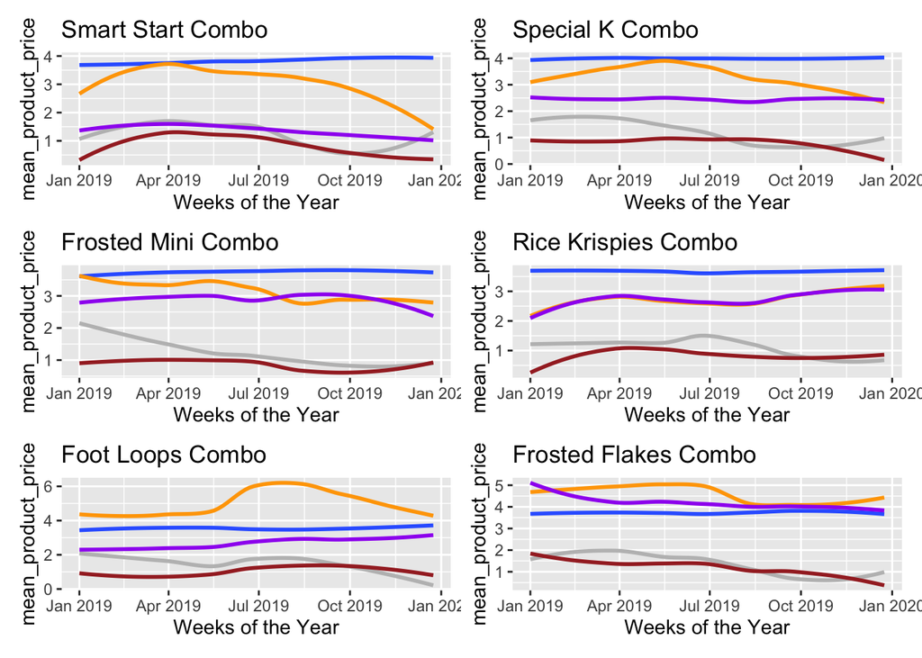

```r
(smart_start_plot + special_k_plot) /
  (frosted_mini_plot + rice_krispies_plot) /
  (fruit_loops_plot + frosted_flakes_plot)
```

## Observations: 1. In general it appears that a decrease in promo, and ads lead a decrease in units sold (Fig 4.2). Promos 2. Foot Loops (#2 Seller) saw a rise in units sold following a bump in Promo and Ads per week (Combo Graph). 3. *SURPRISING* Rice Krispies only brand where units sold mirrors promos. There is a slight bump in units sold the lagging a bump in medium ads (Combo Graph). 4. Ad priority appears to be medium size ads. 5 *SURPRISING* Price appears to follow units sold (as a lag affect) **except** for Smart Start. While units sold decrease price actual increases. There is also a significant investment in medium ads. 6. Smart Start: There is a bump in the spring followed by a gradual decline in units sold as the amateur sport season progresses (Spring, Summer, Fall; 5Ks, 10K, triathlons, etc.). People participating in these activities generally have the income to support more expensive cereal. There is also an increase in ads just prior to the start of the new year training season and the corresponding bump in units sold.

## 7.1 Questions:

1. Are medium ads more effective in influencing units sold?
2. What has the greater influence - ads or promos? It appears that Kellogg consistently goes to ads to offset declines in units sold.
3. Is Smart Start targeted toward a particular segment - say people in to fitness?

# 8 Detailed EDA and Modeling

The following will combine Detailed EDA and Modeling to outline the relationship between ads and units sold and promos and units sold. The multi-variable analysis appears to show a consistent leading relationship between ads and promos and the units sold that relationship seems to vary by brand. The following will look deeper into that relationship.

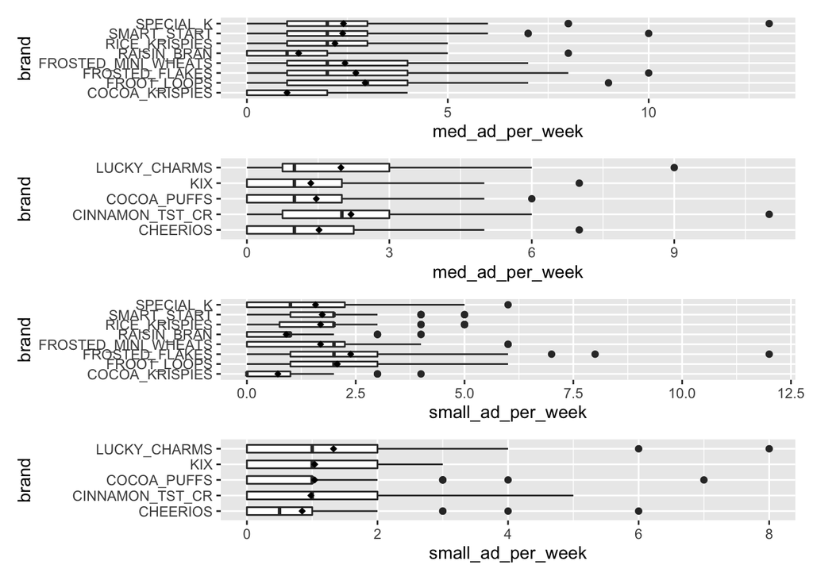

```r
# The following focuses on the impact of ads on units sold. Advertising is a considerable expense and the ROI should be assessed.  The preceding  appears to show a general relationship, it appears inconsistent.

# The analysis begins by examining the interquartile range of ads by brand. The first builds box plots for the number of medium ads per brand.
# There are 4 boxplots.  Two look at small ads and 2 looking a medium ads.  The difference is that they are segregated by maker: Genral Mills and Kelloggs.

# The following build the kelloggs med ad plot.
med_ad_plot <- base_kelloggs_data %>%
  group_by(brand, week_of) %>%
  summarise(med_ad_per_week = sum(ad == "A")) %>%
            # Counts up the total number of medium adds per week.
  ggplot(aes(x = brand, y = med_ad_per_week)) +
  geom_boxplot(width = .5) +
  stat_summary(fun.y = "mean", geom = "point", shape = 23, size = 1, fill = "black") +
  coord_flip()

# The following builds the kellogs small ad plot.
small_ad_plot <- base_kelloggs_data %>%
  group_by(brand, week_of) %>%
  summarise(small_ad_per_week = sum(ad == "B")) %>%
            # Counts up the total number of medium adds per week.
   ggplot(aes(x = brand, y = small_ad_per_week)) +
  geom_boxplot(width = .5) +
  stat_summary(fun.y = "mean", geom = "point", shape = 23, size = 1, fill = "black") +
  coord_flip()

# The following builds the GM med ad plot.
gm_med_ad_plot <- base_cereal_data %>%
  filter(maker == 'GENERAL_MILLS') %>%
  group_by(brand, week_of) %>%
  summarise(med_ad_per_week = sum(ad == "A")) %>%
            # Counts up the total number of medium adds per week.
  ggplot(aes(x = brand, y = med_ad_per_week)) +
  geom_boxplot(width = .5) +
  stat_summary(fun.y = "mean", geom = "point", shape = 23, size = 1, fill = "black") +
  coord_flip()

# The following builds the GM small ad plot.
gm_small_ad_plot <- base_cereal_data %>%
  filter(maker == 'GENERAL_MILLS') %>%
  group_by(brand, week_of) %>%
  summarise(small_ad_per_week = sum(ad == "B")) %>%
            # Counts up the total number of medium adds per week.
  ggplot(aes(x = brand, y = small_ad_per_week)) +
  geom_boxplot(width = .5) +
  stat_summary(fun.y = "mean", geom = "point", shape = 23, size = 1, fill = "black") +
  coord_flip()

# Following bring them together.
med_ad_plot / gm_med_ad_plot / small_ad_plot / gm_small_ad_plot
```

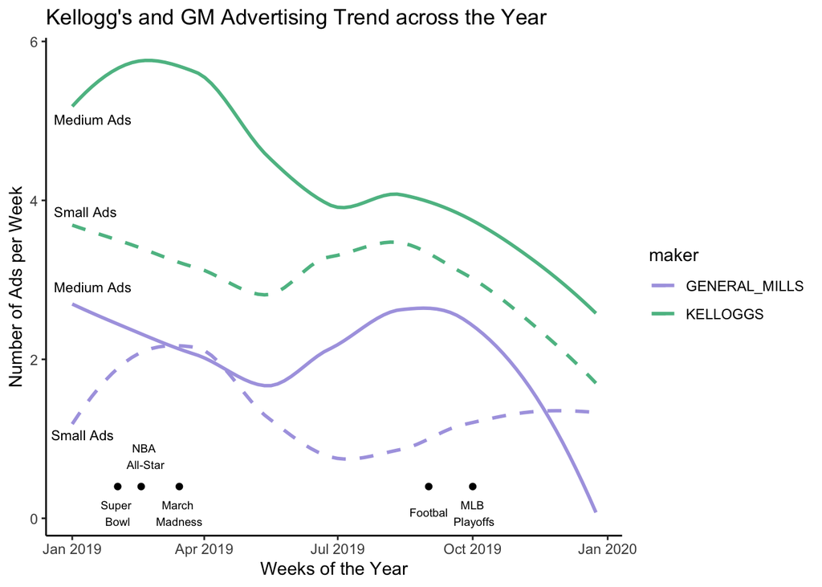

```r
# Figure (Boxplots) confirms Fig 4.2 that Kellogg invested more in medium sized ads than small. It als shows that GM followed the same strategy.
# The following will attempt to model the relationship between ads and units sold.
# The following converts the ad and promo variables into new variables that could be used as dummy variables for bi and multi-variable regressions.
updated_base_cereal_data <- base_cereal_data %>%
  filter(maker == c('GENERAL_MILLS', 'KELLOGGS')) %>%
  mutate(med_ad_buys = case_when(ad == 'A' ~ '1', ad != 'A' ~ '0'),
         sml_ad_buys = case_when(ad == 'B' ~ '1', ad != 'B' ~ '0'),
         promo_per_week = case_when(promo == '1' ~ '1', promo != '1' ~ '0'))

# We assume Kellogs believed medium ads offered bigger ROI. The following examines if there was a relationship between units sold and small and medium ads to see if there is indeed a bigger ROI with medium ads.  Will use median as central tendency. For medium ads the means are pulled right of the median by the outliers. Conversely the means of small ads are bulled left of the median by the low number of ads.

# The not only examines Kellogg's strategy but GMs'.
ad_data <- updated_base_cereal_data %>%
  filter(maker == c("GENERAL_MILLS", "KELLOGGS")) %>%
  group_by(maker, week_of) %>%
  summarise(sold_per_week = sum(units),
            med_ad_per_week = sum(med_ad_buys == "1"),
            # Builds a variable for the mean of medium adds per week.
            small_ad_per_week = sum(sml_ad_buys == "1"))
            # Builds a variable for the  mean of small adds per week

ad_trend_plot <- ad_data %>%
  ggplot(aes(x = week_of, y = med_ad_per_week, color = maker)) +
  #geom_smooth(aes(y = (sold_per_week/100)), se = FALSE) +
  geom_smooth(aes(y = med_ad_per_week), se = FALSE) +
  geom_smooth(aes(y = small_ad_per_week), linetype = 'dashed', se = FALSE) +
  annotate("point", x = as.Date('2019-02-01'), y = .4, colour = "black") +
  annotate("point", x = as.Date('2019-03-15'), y = .4, colour = "black") +
  annotate("point", x = as.Date('2019-02-17'), y = .4, colour = "black") +
  annotate("point", x = as.Date('2019-10-01'), y = .4, colour = "black") +
  annotate("point", x = as.Date('2019-09-01'), y = .4, colour = "black") +
  geom_text(data = data.frame(x = as.Date(c("2019-02-01", "2019-10-02", "2019-03-15", "2019-02-20", "2019-09-01")),
y = c(0.0666238273313096, 0.0666238273313096, 0.0666238273313096, 0.78, 0.0766238273313096),
label = c("Super \nBowl", "MLB \nPlayoffs", "March \nMadness", "NBA \nAll-Star", "Footbal")),
mapping = aes(x = x, y = y, label = label),
size = 2.47, inherit.aes = FALSE) +
geom_text(data = data.frame(x = as.Date(c("2019-01-10", "2019-01-15", "2019-01-08", "2019-01-15")),
y = c(3.85365336823013, 2.9101263621433, 1.05, 5.01807890125769),
label = c("Small Ads", "Medium Ads", "Small Ads", "Medium Ads")),
mapping = aes(x = x, y = y, label = label),
size = 3, inherit.aes = FALSE) +
  scale_color_discrete_qualitative(palette = 'Cold') +
  theme_classic() +
  labs(title = "Kellogg's and GM Advertising Trend across the Year",
       x = "Weeks of the Year",
       y = "Number of Ads per Week")

ggsave("ad_trends.png", plot = ad_trend_plot)
ad_trend_plot
```

```r
# The box plots and graph show that both bought more medium ads. Kelloggs has more which is expected since they have more brands. The buy pattern in interesting. Kelloggs appears to front load their ads during the first half of the year. GM has a split strategy front loading small ad in the first have with medium ad in the summer followed by a decline in the fall.  GM's medium ad decline is more significant than Kelloggs although GM's small ad decline is shallower.
```

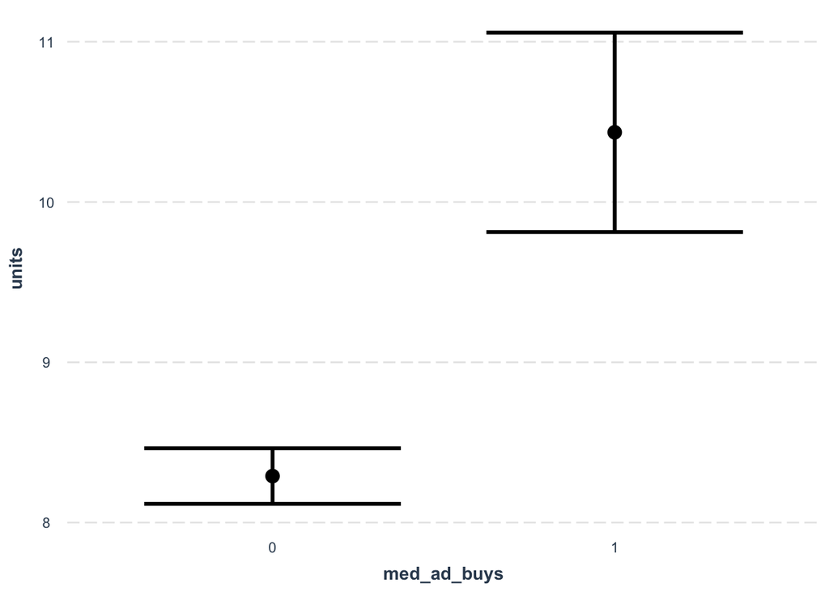

```r
# The previous medium and small ad plots show that GM and Kellogg appears invest more in medium ads than small ads.  The following assess which ad has a bigger influence on units sold.
# The following begins with a bi-variate regression using the new variables to conduct difference of means test between the ad's influence on units sold vice's the influence of no ads. This focuses on kelloggs.

kellogg_df <- updated_base_cereal_data %>%
  filter (maker == 'KELLOGGS')

kellogg_med_ad_lm <- lm(units ~ med_ad_buys, kellogg_df)
effect_plot(kellogg_med_ad_lm, med_ad_buys)
```

```r
export_summs(kellogg_med_ad_lm)
```

|  | Model 1 |
| --- | --- |
| (Intercept) | 8.29 *** |
|  | (0.09) |
| med_ad_buys1 | 2.14 *** |
|  | (0.33) |
| N | 6092 |
| R2 | 0.01 |
| *** p < 0.001; ** p < 0.01; * p < 0.05. |  |

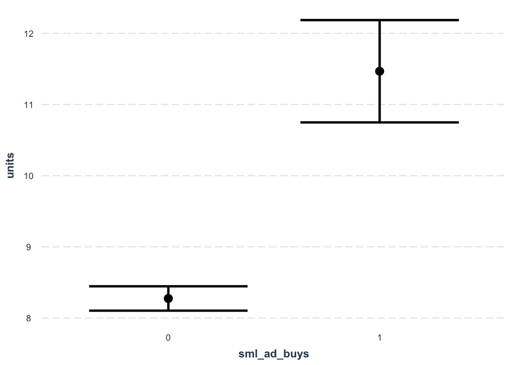

```r
kellogg_small_ad_lm <- lm(units ~ sml_ad_buys, kellogg_df)
effect_plot(kellogg_small_ad_lm, sml_ad_buys)
```

```r
export_summs(kellogg_small_ad_lm)
```

|  | Model 1 |
| --- | --- |
| (Intercept) | 8.27 *** |
|  | (0.09) |
| sml_ad_buys1 | 3.19 *** |
|  | (0.38) |
| N | 6092 |
| R2 | 0.01 |
| *** p < 0.001; ** p < 0.01; * p < 0.05. |  |

```r
#The following model places all three variables in the model.  Over the year small and medium ads and promos are employed in various combinations during each week. There fore we have to assume that there is some type of relationship between the three that can not be shown via correlation models. Bring them all into the model reduces the potential for endogeneity.
kellogg_ad_interaction_lm <- lm(units ~ sml_ad_buys + med_ad_buys + promo_per_week, kellogg_df)
export_summs(kellogg_ad_interaction_lm)
```

|  | Model 1 |
| --- | --- |
| (Intercept) | 7.54 *** |
|  | (0.10) |
| sml_ad_buys1 | 1.95 *** |
|  | (0.38) |
| med_ad_buys1 | 1.46 *** |
|  | (0.33) |
| promo_per_week1 | 2.99 *** |
|  | (0.21) |
| N | 6092 |
| R2 | 0.05 |
| *** p < 0.001; ** p < 0.01; * p < 0.05. |  |